# A4: Regression, Regression Tree and Model Tree

Gaurav Kutemate

Februrary 17th, 2019

# Introduction:

```r
# With plethora prediction models available, it is never easy to decide which model to use. Model selection itself could be a skill and can be honed by practice with different data and variation in functionalities.
# The primary goal of this assignment is to predict the 'sales' of Video games based on different platform. Depending on this analysis, we can decide how would the future versions of a particular a game perform in terms of sale/grossing.

# Target variable: NA_Sales

# Note that our target is Numerical in nature and hence we will use various regression techniques to build a model that will help predict sales of games.
```

# 1.A Set up

## Data import, library initialization, and initial exploration:

```r
#Clear the existing workspace
rm(list = ls())

# All the libraries needed to achieve our goal:
library(rmarkdown)
library(matrixStats)
library(psych)
library(rpart)
library(RWeka)
library(caret)
library(rminer)
library(knitr)

NA_sales_filtered <- read.csv(file="~/Downloads/Data mining/W4/NA_sales_filtered.csv", stringsAsFactors = FALSE)

str(NA_sales_filtered)
```

```
## 'data.frame':    6345 obs. of  9 variables:
##  $ Name        : chr  "Final Fantasy VII" "Final Fantasy X" "The Sims 3" "Final Fantasy VIII" ...
##  $ Platform    : chr  "PS" "PS2" "PC" "PS" ...
##  $ Genre       : chr  "Role-Playing" "Role-Playing" "Simulation" "Role-Playing" ...
##  $ Rating      : chr  "T" "T" "T" "T" ...
##  $ Critic_Score: int  92 92 86 90 96 88 92 96 93 87 ...
##  $ Critic_Count: int  20 53 75 24 15 29 97 105 57 22 ...
##  $ User_Score  : int  91 86 75 85 90 84 82 87 72 80 ...
##  $ User_Count  : int  1282 1056 886 644 367 135 3712 5187 2182 78 ...
##  $ NA_Sales    : num  3.01 2.91 0.99 2.28 3.27 2.93 2.77 3.27 0.08 3.11 ...
```

```r
summary(NA_sales_filtered)
```

```
##      Name             Platform            Genre
##  Length:6345        Length:6345        Length:6345
##  Class :character   Class :character   Class :character
##  Mode  :character   Mode  :character   Mode  :character
##
##
##
##     Rating           Critic_Score    Critic_Count      User_Score
##  Length:6345        Min.   :13.00   Min.   :  3.00   Min.   : 5.00
##  Class :character   1st Qu.:61.00   1st Qu.: 14.00   1st Qu.:64.00
##  Mode  :character   Median :72.00   Median : 25.00   Median :74.00
##                     Mean   :69.82   Mean   : 28.97   Mean   :70.77
##                     3rd Qu.:80.00   3rd Qu.: 40.00   3rd Qu.:81.00
##                     Max.   :98.00   Max.   :113.00   Max.   :95.00
##    User_Count         NA_Sales
##  Min.   :    4.0   Min.   :0.0100
##  1st Qu.:   10.0   1st Qu.:0.0800
##  Median :   24.0   Median :0.1700
##  Mean   :  152.7   Mean   :0.3542
##  3rd Qu.:   77.0   3rd Qu.:0.4100
##  Max.   :10665.0   Max.   :3.4900
```

## 1.A.2 Converting Character variables to Factor variables, removing the ‘name’ variable and verifying the same:

```r
#Removed 'name' variable as we won't need this in our analysis or modelling
NA_sales_filtered <- NA_sales_filtered[-1]

# Characters to factors:
NA_sales_filtered$Platform <- factor(NA_sales_filtered$Platform)
NA_sales_filtered$Genre <- factor(NA_sales_filtered$Genre)
NA_sales_filtered$Rating <-factor(NA_sales_filtered$Rating)

str(NA_sales_filtered)
```

```
## 'data.frame':    6345 obs. of  8 variables:
##  $ Platform    : Factor w/ 16 levels "3DS","DS","GBA",..: 6 7 5 6 6 7 8 8 5 6 ...
##  $ Genre       : Factor w/ 12 levels "Action","Adventure",..: 8 8 10 8 3 9 1 1 8 1 ...
##  $ Rating      : Factor w/ 5 levels "E","E10+","M",..: 5 5 5 5 5 5 5 5 5 5 ...
##  $ Critic_Score: int  92 92 86 90 96 88 92 96 93 87 ...
##  $ Critic_Count: int  20 53 75 24 15 29 97 105 57 22 ...
##  $ User_Score  : int  91 86 75 85 90 84 82 87 72 80 ...
##  $ User_Count  : int  1282 1056 886 644 367 135 3712 5187 2182 78 ...
##  $ NA_Sales    : num  3.01 2.91 0.99 2.28 3.27 2.93 2.77 3.27 0.08 3.11 ...
```

```r
summary(NA_sales_filtered)
```

```
##     Platform             Genre          Rating      Critic_Score
##  PS2    :1135   Action      :1549   E      :1968   Min.   :13.00
##  X360   : 848   Sports      : 921   E10+   : 877   1st Qu.:61.00
##  PS3    : 749   Shooter     : 798   M      :1295   Median :72.00
##  XB     : 578   Role-Playing: 643   missing:  23   Mean   :69.82
##  Wii    : 475   Racing      : 537   T      :2182   3rd Qu.:80.00
##  DS     : 457   Platform    : 386                  Max.   :98.00
##  (Other):2103   (Other)     :1511
##   Critic_Count      User_Score      User_Count         NA_Sales
##  Min.   :  3.00   Min.   : 5.00   Min.   :    4.0   Min.   :0.0100
##  1st Qu.: 14.00   1st Qu.:64.00   1st Qu.:   10.0   1st Qu.:0.0800
##  Median : 25.00   Median :74.00   Median :   24.0   Median :0.1700
##  Mean   : 28.97   Mean   :70.77   Mean   :  152.7   Mean   :0.3542
##  3rd Qu.: 40.00   3rd Qu.:81.00   3rd Qu.:   77.0   3rd Qu.:0.4100
##  Max.   :113.00   Max.   :95.00   Max.   :10665.0   Max.   :3.4900
##
```

## 1.B Exploring the relationship among Numeric vaariables by observing their distribution and correlation:

```r
#Correlation between various numerical variables
cor(NA_sales_filtered[c('Critic_Score', 'Critic_Count', 'User_Score', 'User_Count', 'NA_Sales')])
```

```
##              Critic_Score Critic_Count User_Score User_Count  NA_Sales
## Critic_Score    1.0000000    0.3903993 0.58454759 0.24368767 0.3529736
## Critic_Count    0.3903993    1.0000000 0.19276210 0.34805984 0.3435046
## User_Score      0.5845476    0.1927621 1.00000000 0.01239754 0.1453508
## User_Count      0.2436877    0.3480598 0.01239754 1.00000000 0.2683929
## NA_Sales        0.3529736    0.3435046 0.14535079 0.26839294 1.0000000
```

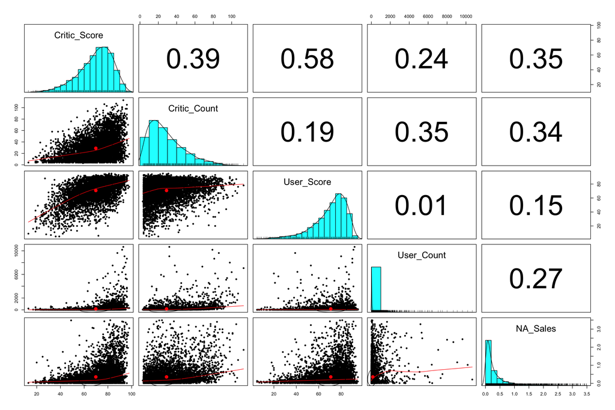

```r
pairs.panels(NA_sales_filtered[c('Critic_Score', 'Critic_Count', 'User_Score', 'User_Count', 'NA_Sales' )])
```

## Note: Here on, the index of our target variable is 8.

## 1.C Building our first prediction model - linear regression model:

```r
lm_base_NA_sales <- lm(NA_Sales ~ ., data = NA_sales_filtered)
summary(lm_base_NA_sales)
```

```
##
## Call:
## lm(formula = NA_Sales ~ ., data = NA_sales_filtered)
##
## Residuals:
##     Min      1Q  Median      3Q     Max
## -1.9381 -0.2315 -0.0818  0.0978  3.1769
##
## Coefficients:
##                     Estimate Std. Error t value Pr(>|t|)
## (Intercept)       -4.045e-01  4.796e-02  -8.435  < 2e-16 ***
## PlatformDS         1.547e-01  4.088e-02   3.783 0.000156 ***
## PlatformGBA        1.705e-01  4.573e-02   3.729 0.000194 ***
## PlatformGC         8.918e-02  4.276e-02   2.085 0.037071 *
## PlatformPC        -3.054e-01  4.554e-02  -6.706 2.17e-11 ***
## PlatformPS         4.075e-01  5.080e-02   8.020 1.25e-15 ***
## PlatformPS2        1.954e-01  3.851e-02   5.074 4.00e-07 ***
## PlatformPS3        9.718e-02  3.929e-02   2.473 0.013422 *
## PlatformPS4       -7.379e-02  4.670e-02  -1.580 0.114165
## PlatformPSP        4.007e-02  4.201e-02   0.954 0.340130
## PlatformPSV       -1.176e-01  5.741e-02  -2.049 0.040509 *
## PlatformWii        2.401e-01  4.070e-02   5.898 3.87e-09 ***
## PlatformWiiU       2.866e-02  5.892e-02   0.487 0.626616
## PlatformX360       1.387e-01  3.906e-02   3.551 0.000386 ***
## PlatformXB         2.122e-02  4.060e-02   0.523 0.601157
## PlatformXOne       1.621e-01  4.988e-02   3.251 0.001157 **
## GenreAdventure    -1.254e-01  3.082e-02  -4.068 4.81e-05 ***
## GenreFighting      3.030e-03  2.539e-02   0.119 0.905002
## GenreMisc          8.375e-02  2.503e-02   3.346 0.000823 ***
## GenrePlatform     -3.135e-02  2.551e-02  -1.229 0.219107
## GenrePuzzle       -1.315e-01  4.298e-02  -3.059 0.002230 **
## GenreRacing       -4.130e-02  2.282e-02  -1.810 0.070341 .
## GenreRole-Playing -1.030e-01  2.038e-02  -5.052 4.50e-07 ***
## GenreShooter       2.908e-03  1.894e-02   0.154 0.877966
## GenreSimulation    5.868e-02  2.951e-02   1.988 0.046825 *
## GenreSports       -2.387e-02  2.134e-02  -1.118 0.263445
## GenreStrategy     -1.726e-01  3.297e-02  -5.235 1.71e-07 ***
## RatingE10+        -5.782e-02  1.888e-02  -3.062 0.002205 **
## RatingM           -1.121e-01  2.107e-02  -5.322 1.06e-07 ***
## Ratingmissing     -2.244e-01  8.975e-02  -2.500 0.012451 *
## RatingT           -9.328e-02  1.679e-02  -5.557 2.86e-08 ***
## Critic_Score       1.049e-02  5.435e-04  19.298  < 2e-16 ***
## Critic_Count       6.122e-03  3.687e-04  16.605  < 2e-16 ***
## User_Score        -2.824e-03  4.930e-04  -5.729 1.06e-08 ***
## User_Count         2.027e-04  1.172e-05  17.287  < 2e-16 ***
## ---
## Signif. codes:  0 '***' 0.001 '**' 0.01 '*' 0.05 '.' 0.1 ' ' 1
##
## Residual standard error: 0.421 on 6310 degrees of freedom
## Multiple R-squared:  0.2787, Adjusted R-squared:  0.2749
## F-statistic: 71.72 on 34 and 6310 DF,  p-value: < 2.2e-16
```

## As we know, R-squared is a goodness-of-fit measure for linear regression models. This statistic indicates the percentage of the variance in the dependent variable that the independent variables explain collectively. R-squared in our case is not extremely bad but could be lot better.

# 1.D Creating data partition to perform modelling:

```r
set.seed(222)

inTrain <- createDataPartition(y=NA_sales_filtered$NA_Sales, p=0.7, list = FALSE)

NA_sales_Train <- NA_sales_filtered[inTrain,] #Training set
NA_sales_Test <- NA_sales_filtered[-inTrain,] #Testing set
```

## 1.E Summary of the Train and Test sets:

```r
summary(NA_sales_Train)
```

```
##     Platform             Genre          Rating      Critic_Score
##  PS2    : 810   Action      :1099   E      :1375   Min.   :13.00
##  X360   : 587   Sports      : 659   E10+   : 598   1st Qu.:61.00
##  PS3    : 531   Shooter     : 548   M      : 898   Median :72.00
##  XB     : 402   Role-Playing: 439   missing:  13   Mean   :69.81
##  Wii    : 340   Racing      : 360   T      :1558   3rd Qu.:80.00
##  DS     : 313   Platform    : 270                  Max.   :98.00
##  (Other):1459   (Other)     :1067
##   Critic_Count      User_Score      User_Count       NA_Sales
##  Min.   :  4.00   Min.   : 6.00   Min.   :    4   Min.   :0.0100
##  1st Qu.: 14.00   1st Qu.:63.25   1st Qu.:   10   1st Qu.:0.0800
##  Median : 24.00   Median :74.00   Median :   24   Median :0.1700
##  Mean   : 28.85   Mean   :70.67   Mean   :  146   Mean   :0.3514
##  3rd Qu.: 39.00   3rd Qu.:81.00   3rd Qu.:   74   3rd Qu.:0.4100
##  Max.   :113.00   Max.   :94.00   Max.   :10665   Max.   :3.4800
##
```

```r
summary(NA_sales_Test)
```

```
##     Platform            Genre         Rating     Critic_Score
##  PS2    :325   Action      :450   E      :593   Min.   :19.00
##  X360   :261   Sports      :262   E10+   :279   1st Qu.:62.00
##  PS3    :218   Shooter     :250   M      :397   Median :72.00
##  XB     :176   Role-Playing:204   missing: 10   Mean   :69.85
##  DS     :144   Racing      :177   T      :624   3rd Qu.:80.00
##  Wii    :135   Platform    :116                 Max.   :96.00
##  (Other):644   (Other)     :444
##   Critic_Count      User_Score      User_Count         NA_Sales
##  Min.   :  3.00   Min.   : 5.00   Min.   :    4.0   Min.   :0.0100
##  1st Qu.: 14.00   1st Qu.:64.00   1st Qu.:   10.5   1st Qu.:0.0800
##  Median : 25.00   Median :75.00   Median :   25.0   Median :0.1700
##  Mean   : 29.25   Mean   :70.99   Mean   :  168.4   Mean   :0.3608
##  3rd Qu.: 40.00   3rd Qu.:81.00   3rd Qu.:   82.5   3rd Qu.:0.4100
##  Max.   :105.00   Max.   :95.00   Max.   :10179.0   Max.   :3.4900
##
```

# 2.A&B. Generating Various models on Train set. Applying these model on respective Test sets and evaluating these prediction models through metrics:

## 2.A&B.1 Linear model:

```r
lm_NA_sales <- lm(NA_sales_Train$NA_Sales~., data = NA_sales_Train)
summary(lm_NA_sales)
```

```
##
## Call:
## lm(formula = NA_sales_Train$NA_Sales ~ ., data = NA_sales_Train)
##
## Residuals:
##     Min      1Q  Median      3Q     Max
## -1.9367 -0.2270 -0.0805  0.0944  3.1981
##
## Coefficients:
##                     Estimate Std. Error t value Pr(>|t|)
## (Intercept)       -0.4209964  0.0562189  -7.489 8.37e-14 ***
## PlatformDS         0.1390650  0.0480663   2.893 0.003832 **
## PlatformGBA        0.1704792  0.0540964   3.151 0.001636 **
## PlatformGC         0.1068621  0.0499901   2.138 0.032599 *
## PlatformPC        -0.2673488  0.0538459  -4.965 7.13e-07 ***
## PlatformPS         0.4335264  0.0600676   7.217 6.21e-13 ***
## PlatformPS2        0.2066359  0.0450280   4.589 4.58e-06 ***
## PlatformPS3        0.1004122  0.0459407   2.186 0.028891 *
## PlatformPS4       -0.0333012  0.0560299  -0.594 0.552310
## PlatformPSP        0.0454807  0.0489791   0.929 0.353161
## PlatformPSV       -0.1168070  0.0682102  -1.712 0.086883 .
## PlatformWii        0.2366801  0.0476267   4.969 6.97e-07 ***
## PlatformWiiU       0.0524413  0.0686393   0.764 0.444901
## PlatformX360       0.1376271  0.0457136   3.011 0.002622 **
## PlatformXB         0.0331971  0.0475828   0.698 0.485420
## PlatformXOne       0.1817208  0.0605807   3.000 0.002718 **
## GenreAdventure    -0.1283498  0.0362198  -3.544 0.000399 ***
## GenreFighting     -0.0012576  0.0302717  -0.042 0.966864
## GenreMisc          0.0659296  0.0295140   2.234 0.025544 *
## GenrePlatform     -0.0598462  0.0302022  -1.982 0.047596 *
## GenrePuzzle       -0.1722579  0.0507686  -3.393 0.000697 ***
## GenreRacing       -0.0382284  0.0274325  -1.394 0.163525
## GenreRole-Playing -0.1131216  0.0243516  -4.645 3.49e-06 ***
## GenreShooter       0.0029878  0.0225358   0.133 0.894531
## GenreSimulation    0.0595547  0.0351867   1.693 0.090615 .
## GenreSports       -0.0229289  0.0251147  -0.913 0.361310
## GenreStrategy     -0.1943905  0.0379794  -5.118 3.21e-07 ***
## RatingE10+        -0.0630697  0.0226022  -2.790 0.005286 **
## RatingM           -0.1253006  0.0249980  -5.012 5.59e-07 ***
## Ratingmissing     -0.2105352  0.1185155  -1.776 0.075730 .
## RatingT           -0.0922864  0.0198596  -4.647 3.47e-06 ***
## Critic_Score       0.0103711  0.0006437  16.111  < 2e-16 ***
## Critic_Count       0.0060380  0.0004388  13.761  < 2e-16 ***
## User_Score        -0.0024522  0.0005777  -4.245 2.23e-05 ***
## User_Count         0.0002008  0.0000145  13.846  < 2e-16 ***
## ---
## Signif. codes:  0 '***' 0.001 '**' 0.01 '*' 0.05 '.' 0.1 ' ' 1
##
## Residual standard error: 0.4179 on 4407 degrees of freedom
## Multiple R-squared:  0.2735, Adjusted R-squared:  0.2679
## F-statistic:  48.8 on 34 and 4407 DF,  p-value: < 2.2e-16
```

## linear prediction models:

```r
prediction_lm_test <- predict(lm_NA_sales, NA_sales_Test[c(-8)])
summary(prediction_lm_test)
```

```
##    Min. 1st Qu.  Median    Mean 3rd Qu.    Max.
## -0.4895  0.1918  0.3436  0.3563  0.5023  2.5591
```

```r
prediction_lm_train <- predict(lm_NA_sales, NA_sales_Train[c(-8)])
summary(prediction_lm_train)
```

```
##    Min. 1st Qu.  Median    Mean 3rd Qu.    Max.
## -0.4894  0.1834  0.3411  0.3514  0.4992  2.5173
```

## Explanatory and Predictive Error evaluation metrics:

```r
# performance of predictions on testing data
mmetric(NA_sales_Test$NA_Sales,prediction_lm_test,c("MAE","RMSE","MAPE","RMSPE","RAE", "RRSE", "COR", "R2"))
```

```
##         MAE        RMSE        MAPE       RMSPE         RAE        RRSE
##   0.2743963   0.4294664 264.7368016  69.7687122  83.3556562  84.5169966
##         COR          R2
##   0.5345977   0.2857947
```

```r
# performance of predictions on training data
mmetric(NA_sales_Train$NA_Sales,prediction_lm_train,c("MAE","RMSE","MAPE","RMSPE","RAE", "RRSE", "COR", "R2"))
```

```
##         MAE        RMSE        MAPE       RMSPE         RAE        RRSE
##   0.2662402   0.4162125 250.2279903  57.8687699  83.9703530  85.2340473
##         COR          R2
##   0.5229873   0.2735157
```

## 2.A&B.2 Regression Tree model(rPart):

```r
rpart_NA_sales <- rpart(NA_sales_Train$NA_Sales~., data = NA_sales_Train)
rpart_NA_sales
```

```
## n= 4442
##
## node), split, n, deviance, yval
##       * denotes terminal node
##
##   1) root 4442 1059.21100 0.3514295
##     2) User_Count< 77.5 3363  346.84460 0.2467678
##       4) Critic_Score< 78.5 2683  180.78880 0.2043123 *
##       5) Critic_Score>=78.5 680  142.13880 0.4142794 *
##     3) User_Count>=77.5 1079  560.71030 0.6776367
##       6) Critic_Score< 81.5 567  134.25410 0.4493298
##        12) Platform=3DS,DS,PC,PS3,PS4,PSP,PSV,WiiU,X360,XB,XOne 503   87.35866 0.3812922 *
##        13) Platform=GBA,GC,PS,PS2,Wii 64   26.26694 0.9840625 *
##       7) Critic_Score>=81.5 512  364.17270 0.9304687
##        14) Platform=3DS,PC,PSV 96   24.96807 0.3094792 *
##        15) Platform=DS,GBA,GC,PS,PS2,PS3,PS4,PSP,Wii,WiiU,X360,XB,XOne 416  293.64120 1.0737740
##          30) User_Count< 688.5 329  190.32640 0.9316109
##            60) Rating=E10+,M,missing 136   46.15198 0.6767647 *
##            61) Rating=E,T 193  129.11760 1.1111920
##             122) Platform=DS,GBA,GC,PS3,PS4,PSP,WiiU,XOne 88   34.61045 0.7625000 *
##             123) Platform=PS,PS2,Wii,X360,XB 105   74.84037 1.4034290 *
##          31) User_Count>=688.5 87   71.52083 1.6113790 *
```

## rpart prediction model

```r
predictions_rpart_test <- predict(rpart_NA_sales, NA_sales_Test)
summary(predictions_rpart_test)
```

```
##    Min. 1st Qu.  Median    Mean 3rd Qu.    Max.
##  0.2043  0.2043  0.2043  0.3563  0.4143  1.6114
```

```r
predictions_rpart_train <- predict(rpart_NA_sales, NA_sales_Train)
summary(predictions_rpart_train)
```

```
##    Min. 1st Qu.  Median    Mean 3rd Qu.    Max.
##  0.2043  0.2043  0.2043  0.3514  0.4143  1.6114
```

## Generating Regression tree prediction performance metrics:

```r
# Performance of predictions on test data
mmetric(NA_sales_Test$NA_Sales, predictions_rpart_test,c("MAE","RMSE","MAPE","RMSPE","RAE", "RRSE","COR", "R2"))
```

```
##         MAE        RMSE        MAPE       RMSPE         RAE        RRSE
##   0.2691260   0.4379259 267.5329264  60.9214662  81.7546362  86.1817795
##         COR          R2
##   0.5119750   0.2621184
```

```r
# Performance of predictions on train data
mmetric(NA_sales_Train$NA_Sales,predictions_rpart_train,c("MAE","RMSE","MAPE","RMSPE","RAE", "RRSE","COR", "R2"))
```

```
##         MAE        RMSE        MAPE       RMSPE         RAE        RRSE
##   0.2498314   0.3937390 256.6745865  59.2146967  78.7951415  80.6318158
##         COR          R2
##   0.5914821   0.3498510
```

## 2.A&B.3 Model tree - M5P (RWeka)

```r
m5p_NA_sales <- M5P(NA_sales_Train$NA_Sales~., data = NA_sales_Train[c(-8)])
summary(m5p_NA_sales)
```

```
##
## === Summary ===
##
## Correlation coefficient                  0.6254
## Mean absolute error                      0.2343
## Root mean squared error                  0.381
## Relative absolute error                 73.8811 %
## Root relative squared error             78.0318 %
## Total Number of Instances             4442
```

## M5P: Prediction models:

```r
predictions_m5p_test <- predict(m5p_NA_sales, NA_sales_Test)
summary(predictions_m5p_test)
```

```
##    Min. 1st Qu.  Median    Mean 3rd Qu.    Max.
## -0.5343  0.1390  0.2634  0.3558  0.5153  2.4216
```

```r
predictions_m5p_train <- predict(m5p_NA_sales, NA_sales_Train)
summary(predictions_m5p_train)
```

```
##    Min. 1st Qu.  Median    Mean 3rd Qu.    Max.
## -0.5974  0.1422  0.2565  0.3511  0.5057  2.4559
```

## Model prediction and explanatory evaluation metrics:

```r
# Generating prediction performance metrics using rminer package
# Performance of predictions on test and train data
mmetric(NA_sales_Test$NA_Sales,predictions_m5p_test,c("MAE","RMSE","MAPE","RMSPE","RAE","RRSE","COR","R2"))
```

```
##         MAE        RMSE        MAPE       RMSPE         RAE        RRSE
##   0.2520069   0.4104396 231.3593875  68.8991796  76.5542289  80.7726119
##         COR          R2
##   0.5900727   0.3481858
```

```r
mmetric(NA_sales_Train$NA_Sales,predictions_m5p_train,c("MAE","RMSE","MAPE","RMSPE","RAE","RRSE","COR","R2"))
```

```
##         MAE        RMSE        MAPE       RMSPE         RAE        RRSE
##   0.2342506   0.3810425 209.6488909  56.9200740  73.8810643  78.0317632
##         COR          R2
##   0.6254391   0.3911740
```

# 3.A Corss validation: This is a technique used in model selection to better estimate the test error of a predictive model. The idea behind cross-validation is to create a number of partitions of sample observations, known as the validation sets/folds, from the training data set.

# We can achieve Cross validation using ‘loop’ commands or ‘lapply’ and functions.

# Now, we create a cross-validation Function – ‘cv_function’. We do this so that we can reuse the function depending on our preference of Model and no. of folds.

```r
# Creating a cv_function with input arguments that could be altered for re-use.

cv_function <- function(df, target, nFolds, seedVal, prediction_method, metrics_list)
{
  # create folds
  set.seed(seedVal)
  folds = createFolds(df[,target],nFolds)
  # perform cross validation
  cv_results <- lapply(folds, function(x)
  {
    test_target <- df[x,target]
    test_input  <- df[x,-target]

    train_target <- df[-x,target]
    train_input <- df[-x,-target]

    prediction_model <- prediction_method(train_target~.,train_input)
    pred<- predict(prediction_model,test_input)
    return(mmetric(test_target,pred,metrics_list))
  })
  # generate means and sds and show cv results, means and sds using kable
  cv_results_m <- as.matrix(as.data.frame(cv_results))
  cv_mean<- as.matrix(rowMeans(cv_results_m))
  cv_sd <- as.matrix(rowSds(cv_results_m))
  colnames(cv_mean) <- "Mean"
  colnames(cv_sd) <- "Sd"
  cv_all <- cbind(cv_results_m, cv_mean, cv_sd)
  kable(t(cv_all),digits=2)
}
```

# Now that we have our cross vaidation function defined, we can apply it on different regression models across no. of folds.

# Hence, we use our cv_function to evaluate ‘linear’, ‘rpart’ and ‘M5P’ models by 5-fold cross-validation.

# 3.B Applying our cross validation function with 5-fold to our 3 models under consideration:

## 3.B.1 Linear model:

```r
df <- NA_sales_filtered
target <- 8
nFolds <- 5
seedVal <- 222
assign("prediction_method", lm)
metrics_list <- c("MAE","RMSE","MAPE","RMSPE","RAE","RRSE","R2")

cv_function(df, target, nFolds, seedVal, prediction_method, metrics_list)
```

|  | MAE | RMSE | MAPE | RMSPE | RAE | RRSE | R2 |
| --- | --- | --- | --- | --- | --- | --- | --- |
| Fold1 | 0.29 | 0.45 | 266.98 | 57.81 | 85.79 | 86.04 | 0.26 |
| Fold2 | 0.26 | 0.39 | 267.79 | 70.70 | 85.95 | 84.04 | 0.30 |
| Fold3 | 0.28 | 0.46 | 262.44 | 61.99 | 83.10 | 86.96 | 0.24 |
| Fold4 | 0.27 | 0.42 | 242.41 | 50.87 | 84.81 | 86.02 | 0.26 |
| Fold5 | 0.26 | 0.40 | 236.20 | 65.64 | 82.19 | 84.09 | 0.29 |
| Mean | 0.27 | 0.42 | 255.17 | 61.40 | 84.37 | 85.43 | 0.27 |
| Sd | 0.01 | 0.03 | 14.79 | 7.56 | 1.66 | 1.30 | 0.02 |

## 3.B.2 Regression Tree(rpart) model:

```r
assign("prediction_method", rpart)
cv_function(df, target, nFolds, seedVal, prediction_method, metrics_list)
```

|  | MAE | RMSE | MAPE | RMSPE | RAE | RRSE | R2 |
| --- | --- | --- | --- | --- | --- | --- | --- |
| Fold1 | 0.28 | 0.45 | 251.51 | 57.07 | 82.27 | 86.08 | 0.26 |
| Fold2 | 0.25 | 0.38 | 268.01 | 67.44 | 82.58 | 82.92 | 0.32 |
| Fold3 | 0.27 | 0.45 | 248.44 | 56.79 | 78.82 | 86.17 | 0.26 |
| Fold4 | 0.26 | 0.43 | 244.88 | 59.71 | 82.35 | 89.15 | 0.23 |
| Fold5 | 0.25 | 0.39 | 247.15 | 54.59 | 80.47 | 81.76 | 0.33 |
| Mean | 0.26 | 0.42 | 252.00 | 59.12 | 81.30 | 85.22 | 0.28 |
| Sd | 0.01 | 0.03 | 9.27 | 4.99 | 1.62 | 2.93 | 0.04 |

## 3.B.3 Model tree(M5P) model:

```r
assign("prediction_method", M5P)
cv_function(df, target, nFolds, seedVal, prediction_method, metrics_list)
```

|  | MAE | RMSE | MAPE | RMSPE | RAE | RRSE | R2 |
| --- | --- | --- | --- | --- | --- | --- | --- |
| Fold1 | 0.24 | 0.40 | 196.81 | 46.52 | 72.74 | 76.60 | 0.41 |
| Fold2 | 0.22 | 0.35 | 213.61 | 61.52 | 71.65 | 74.88 | 0.44 |
| Fold3 | 0.27 | 0.48 | 207.36 | 59.94 | 80.76 | 90.88 | 0.27 |
| Fold4 | 0.23 | 0.38 | 181.10 | 42.98 | 72.55 | 78.89 | 0.38 |
| Fold5 | 0.23 | 0.38 | 181.36 | 53.66 | 72.60 | 79.24 | 0.39 |
| Mean | 0.24 | 0.40 | 196.05 | 52.92 | 74.06 | 80.10 | 0.38 |
| Sd | 0.02 | 0.05 | 14.80 | 8.12 | 3.77 | 6.28 | 0.07 |

# Regression model Improvement techniques:

```r
# As we have seen from previous Linear models that our R-squared and evaluation metrics could be improved, relation between our target variable and a feature is possibly non-linear. Hence to account for non-linearity in a linear model we can add quadratic terms or log transformation.
```

# 4. Model improvement through Quadratic term:

## 4.A Creating the quadratic version of ‘User_Count’ predictor variable:

```r
NA_sales_filtered$quad_User_Count <- NA_sales_filtered$User_Count^2
summary(NA_sales_filtered)
```

```
##     Platform             Genre          Rating      Critic_Score
##  PS2    :1135   Action      :1549   E      :1968   Min.   :13.00
##  X360   : 848   Sports      : 921   E10+   : 877   1st Qu.:61.00
##  PS3    : 749   Shooter     : 798   M      :1295   Median :72.00
##  XB     : 578   Role-Playing: 643   missing:  23   Mean   :69.82
##  Wii    : 475   Racing      : 537   T      :2182   3rd Qu.:80.00
##  DS     : 457   Platform    : 386                  Max.   :98.00
##  (Other):2103   (Other)     :1511
##   Critic_Count      User_Score      User_Count         NA_Sales
##  Min.   :  3.00   Min.   : 5.00   Min.   :    4.0   Min.   :0.0100
##  1st Qu.: 14.00   1st Qu.:64.00   1st Qu.:   10.0   1st Qu.:0.0800
##  Median : 25.00   Median :74.00   Median :   24.0   Median :0.1700
##  Mean   : 28.97   Mean   :70.77   Mean   :  152.7   Mean   :0.3542
##  3rd Qu.: 40.00   3rd Qu.:81.00   3rd Qu.:   77.0   3rd Qu.:0.4100
##  Max.   :113.00   Max.   :95.00   Max.   :10665.0   Max.   :3.4900
##
##  quad_User_Count
##  Min.   :       16
##  1st Qu.:      100
##  Median :      576
##  Mean   :   321355
##  3rd Qu.:     5929
##  Max.   :113742225
##
```

## Note the difference between ‘User_Count’ and ‘quad_User_Count’.

## 4.B Linear model with quad variable:

```r
lm1_improved <- lm(NA_sales_filtered$NA_Sales~., NA_sales_filtered)
summary(lm1_improved)
```

```
##
## Call:
## lm(formula = NA_sales_filtered$NA_Sales ~ ., data = NA_sales_filtered)
##
## Residuals:
##      Min       1Q   Median       3Q      Max
## -1.30285 -0.22323 -0.08064  0.09633  3.11466
##
## Coefficients:
##                     Estimate Std. Error t value Pr(>|t|)
## (Intercept)       -3.674e-01  4.714e-02  -7.794 7.57e-15 ***
## PlatformDS         1.589e-01  4.013e-02   3.959 7.59e-05 ***
## PlatformGBA        1.714e-01  4.489e-02   3.818 0.000136 ***
## PlatformGC         9.495e-02  4.198e-02   2.262 0.023751 *
## PlatformPC        -4.176e-01  4.529e-02  -9.220  < 2e-16 ***
## PlatformPS         3.912e-01  4.988e-02   7.842 5.16e-15 ***
## PlatformPS2        2.021e-01  3.781e-02   5.346 9.32e-08 ***
## PlatformPS3        8.887e-02  3.858e-02   2.304 0.021272 *
## PlatformPS4       -1.218e-01  4.595e-02  -2.649 0.008082 **
## PlatformPSP        5.061e-02  4.124e-02   1.227 0.219781
## PlatformPSV       -1.242e-01  5.636e-02  -2.204 0.027531 *
## PlatformWii        2.384e-01  3.996e-02   5.966 2.56e-09 ***
## PlatformWiiU      -1.456e-02  5.790e-02  -0.252 0.801426
## PlatformX360       1.454e-01  3.835e-02   3.792 0.000151 ***
## PlatformXB         4.531e-02  3.989e-02   1.136 0.256025
## PlatformXOne       1.113e-01  4.907e-02   2.267 0.023425 *
## GenreAdventure    -1.256e-01  3.025e-02  -4.151 3.35e-05 ***
## GenreFighting      1.438e-02  2.493e-02   0.577 0.564196
## GenreMisc          9.942e-02  2.459e-02   4.043 5.33e-05 ***
## GenrePlatform     -3.036e-02  2.504e-02  -1.212 0.225442
## GenrePuzzle       -1.106e-01  4.222e-02  -2.620 0.008802 **
## GenreRacing       -3.519e-02  2.240e-02  -1.570 0.116358
## GenreRole-Playing -1.034e-01  2.001e-02  -5.171 2.40e-07 ***
## GenreShooter       3.895e-03  1.859e-02   0.210 0.834061
## GenreSimulation    7.724e-02  2.900e-02   2.664 0.007748 **
## GenreSports       -8.697e-03  2.098e-02  -0.415 0.678419
## GenreStrategy     -1.660e-01  3.237e-02  -5.127 3.03e-07 ***
## RatingE10+        -4.985e-02  1.854e-02  -2.688 0.007199 **
## RatingM           -1.361e-01  2.074e-02  -6.565 5.64e-11 ***
## Ratingmissing     -2.153e-01  8.811e-02  -2.444 0.014564 *
## RatingT           -9.029e-02  1.648e-02  -5.479 4.44e-08 ***
## Critic_Score       9.443e-03  5.378e-04  17.559  < 2e-16 ***
## Critic_Count       4.838e-03  3.714e-04  13.028  < 2e-16 ***
## User_Score        -2.256e-03  4.853e-04  -4.648 3.42e-06 ***
## User_Count         5.392e-04  2.463e-05  21.889  < 2e-16 ***
## quad_User_Count   -5.215e-08  3.375e-09 -15.451  < 2e-16 ***
## ---
## Signif. codes:  0 '***' 0.001 '**' 0.01 '*' 0.05 '.' 0.1 ' ' 1
##
## Residual standard error: 0.4133 on 6309 degrees of freedom
## Multiple R-squared:  0.305,  Adjusted R-squared:  0.3012
## F-statistic: 79.12 on 35 and 6309 DF,  p-value: < 2.2e-16
```

## Note the performace of improvement i.e. R-squared for base linear model in chunk 1.C. has improved from 0.278 to 0.305.

## 4.C.1 Calling the Cross validation function defined earlier to evaluate metrics with quadratic term added:

```r
df <- NA_sales_filtered
target <- 8
nFolds <- 5
seedVal <- 222
assign("prediction_method", lm)
metrics_list <- c("MAE","RMSE","MAPE","RMSPE","RAE","RRSE","R2")

cv_function(df, target, nFolds, seedVal, prediction_method, metrics_list)
```

|  | MAE | RMSE | MAPE | RMSPE | RAE | RRSE | R2 |
| --- | --- | --- | --- | --- | --- | --- | --- |
| Fold1 | 0.28 | 0.44 | 276.78 | 62.62 | 84.13 | 84.78 | 0.28 |
| Fold2 | 0.26 | 0.39 | 291.09 | 88.24 | 85.04 | 83.49 | 0.31 |
| Fold3 | 0.28 | 0.45 | 259.59 | 67.07 | 81.56 | 85.90 | 0.26 |
| Fold4 | 0.26 | 0.41 | 245.56 | 53.22 | 82.79 | 83.84 | 0.30 |
| Fold5 | 0.25 | 0.39 | 241.17 | 65.55 | 80.85 | 82.47 | 0.32 |
| Mean | 0.27 | 0.42 | 262.84 | 67.34 | 82.87 | 84.09 | 0.29 |
| Sd | 0.01 | 0.03 | 21.04 | 12.86 | 1.74 | 1.30 | 0.02 |

## 4.C.2 Regression Tree model:

```r
df <- NA_sales_filtered
target <- 8
nFolds <- 5
seedVal <- 222
assign("prediction_method", rpart)
metrics_list <- c("MAE","RMSE","MAPE","RMSPE","RAE","RRSE","R2")

cv_function(df, target, nFolds, seedVal, prediction_method, metrics_list)
```

|  | MAE | RMSE | MAPE | RMSPE | RAE | RRSE | R2 |
| --- | --- | --- | --- | --- | --- | --- | --- |
| Fold1 | 0.28 | 0.45 | 251.51 | 57.07 | 82.27 | 86.08 | 0.26 |
| Fold2 | 0.25 | 0.38 | 268.01 | 67.44 | 82.58 | 82.92 | 0.32 |
| Fold3 | 0.27 | 0.45 | 248.44 | 56.79 | 78.82 | 86.17 | 0.26 |
| Fold4 | 0.26 | 0.43 | 244.88 | 59.71 | 82.35 | 89.15 | 0.23 |
| Fold5 | 0.25 | 0.39 | 247.15 | 54.59 | 80.47 | 81.76 | 0.33 |
| Mean | 0.26 | 0.42 | 252.00 | 59.12 | 81.30 | 85.22 | 0.28 |
| Sd | 0.01 | 0.03 | 9.27 | 4.99 | 1.62 | 2.93 | 0.04 |

## 4.C.3 Model-Tree(M5P) model:

```r
df <- NA_sales_filtered
target <- 8
nFolds <- 5
seedVal <- 222
assign("prediction_method", M5P)
metrics_list <- c("MAE","RMSE","MAPE","RMSPE","RAE","RRSE","R2")

cv_function(df, target, nFolds, seedVal, prediction_method, metrics_list)
```

|  | MAE | RMSE | MAPE | RMSPE | RAE | RRSE | R2 |
| --- | --- | --- | --- | --- | --- | --- | --- |
| Fold1 | 0.24 | 0.40 | 196.05 | 46.36 | 72.64 | 76.53 | 0.42 |
| Fold2 | 0.22 | 0.35 | 213.46 | 61.44 | 71.74 | 74.89 | 0.44 |
| Fold3 | 0.24 | 0.41 | 201.94 | 53.71 | 71.15 | 77.90 | 0.39 |
| Fold4 | 0.23 | 0.38 | 181.10 | 42.98 | 72.55 | 78.89 | 0.38 |
| Fold5 | 0.23 | 0.38 | 181.32 | 53.64 | 72.60 | 79.24 | 0.39 |
| Mean | 0.23 | 0.38 | 194.77 | 51.63 | 72.14 | 77.49 | 0.40 |
| Sd | 0.01 | 0.02 | 13.88 | 7.20 | 0.67 | 1.80 | 0.02 |

# 5. We further try to improve our various prediction models with the addition of ‘log’ of User_Count variable:

## 5.A

```r
NA_sales_filtered$log_User_Count <- log(NA_sales_filtered$User_Count)

# To better analyze the effect of addition of log variable, we remove the original User_Count and quad_User_Count variable:
NA_sales_filtered <- NA_sales_filtered[c(-7,-9)]
summary(NA_sales_filtered) # Quick look of the tranformations done
```

```
##     Platform             Genre          Rating      Critic_Score
##  PS2    :1135   Action      :1549   E      :1968   Min.   :13.00
##  X360   : 848   Sports      : 921   E10+   : 877   1st Qu.:61.00
##  PS3    : 749   Shooter     : 798   M      :1295   Median :72.00
##  XB     : 578   Role-Playing: 643   missing:  23   Mean   :69.82
##  Wii    : 475   Racing      : 537   T      :2182   3rd Qu.:80.00
##  DS     : 457   Platform    : 386                  Max.   :98.00
##  (Other):2103   (Other)     :1511
##   Critic_Count      User_Score       NA_Sales      log_User_Count
##  Min.   :  3.00   Min.   : 5.00   Min.   :0.0100   Min.   :1.386
##  1st Qu.: 14.00   1st Qu.:64.00   1st Qu.:0.0800   1st Qu.:2.303
##  Median : 25.00   Median :74.00   Median :0.1700   Median :3.178
##  Mean   : 28.97   Mean   :70.77   Mean   :0.3542   Mean   :3.483
##  3rd Qu.: 40.00   3rd Qu.:81.00   3rd Qu.:0.4100   3rd Qu.:4.344
##  Max.   :113.00   Max.   :95.00   Max.   :3.4900   Max.   :9.275
##
```

## 5.B Generating 3rd linear model with above transformation:

```r
lm2_improved <- lm(NA_sales_filtered$NA_Sales ~., NA_sales_filtered)
summary(lm2_improved)
```

```
##
## Call:
## lm(formula = NA_sales_filtered$NA_Sales ~ ., data = NA_sales_filtered)
##
## Residuals:
##      Min       1Q   Median       3Q      Max
## -1.16775 -0.21884 -0.05606  0.11205  2.95137
##
## Coefficients:
##                     Estimate Std. Error t value Pr(>|t|)
## (Intercept)       -0.7105139  0.0456105 -15.578  < 2e-16 ***
## PlatformDS         0.2915872  0.0386160   7.551 4.93e-14 ***
## PlatformGBA        0.3498446  0.0432439   8.090 7.10e-16 ***
## PlatformGC         0.2585377  0.0404665   6.389 1.79e-10 ***
## PlatformPC        -0.4721270  0.0428863 -11.009  < 2e-16 ***
## PlatformPS         0.4537101  0.0477305   9.506  < 2e-16 ***
## PlatformPS2        0.3136518  0.0363453   8.630  < 2e-16 ***
## PlatformPS3        0.1002933  0.0369294   2.716 0.006629 **
## PlatformPS4       -0.1604900  0.0439633  -3.651 0.000264 ***
## PlatformPSP        0.1791218  0.0396930   4.513 6.52e-06 ***
## PlatformPSV       -0.1910748  0.0540042  -3.538 0.000406 ***
## PlatformWii        0.3195813  0.0383005   8.344  < 2e-16 ***
## PlatformWiiU      -0.1191096  0.0555939  -2.142 0.032192 *
## PlatformX360       0.1710336  0.0367330   4.656 3.29e-06 ***
## PlatformXB         0.2691929  0.0388955   6.921 4.93e-12 ***
## PlatformXOne       0.0034733  0.0471871   0.074 0.941325
## GenreAdventure    -0.0921240  0.0289801  -3.179 0.001486 **
## GenreFighting      0.0055314  0.0238608   0.232 0.816684
## GenreMisc          0.1541242  0.0236266   6.523 7.41e-11 ***
## GenrePlatform     -0.0673533  0.0240007  -2.806 0.005027 **
## GenrePuzzle       -0.0312015  0.0405350  -0.770 0.441481
## GenreRacing       -0.0312397  0.0214504  -1.456 0.145340
## GenreRole-Playing -0.1612647  0.0192597  -8.373  < 2e-16 ***
## GenreShooter      -0.0051386  0.0178024  -0.289 0.772862
## GenreSimulation    0.1028721  0.0277802   3.703 0.000215 ***
## GenreSports        0.0251585  0.0201269   1.250 0.211347
## GenreStrategy     -0.1691958  0.0309866  -5.460 4.93e-08 ***
## RatingE10+        -0.0354959  0.0177622  -1.998 0.045717 *
## RatingM           -0.2114035  0.0200892 -10.523  < 2e-16 ***
## Ratingmissing     -0.2797779  0.0843576  -3.317 0.000916 ***
## RatingT           -0.1094481  0.0157729  -6.939 4.34e-12 ***
## Critic_Score       0.0059278  0.0005337  11.108  < 2e-16 ***
## Critic_Count       0.0009289  0.0003896   2.384 0.017153 *
## User_Score        -0.0025540  0.0004622  -5.525 3.42e-08 ***
## log_User_Count     0.2094550  0.0061202  34.224  < 2e-16 ***
## ---
## Signif. codes:  0 '***' 0.001 '**' 0.01 '*' 0.05 '.' 0.1 ' ' 1
##
## Residual standard error: 0.3957 on 6310 degrees of freedom
## Multiple R-squared:  0.3628, Adjusted R-squared:  0.3594
## F-statistic: 105.7 on 34 and 6310 DF,  p-value: < 2.2e-16
```

## From above output, we can observe that the R-squared has significantly improved from 0.278(base) to 0.305(lm1) to 0.364(lm2_improved)

## 5.C.1 Applying cross validation function again with log_ User_Count as one of the predictor variables:

## Linear model:

```r
df <- NA_sales_filtered
target <- 7
nFolds <- 5
seedVal <- 222
assign("prediction_method", lm)
metrics_list <- c("MAE","RMSE","MAPE","RMSPE","RAE","RRSE","R2")

cv_function(df, target, nFolds, seedVal, prediction_method, metrics_list)
```

|  | MAE | RMSE | MAPE | RMSPE | RAE | RRSE | R2 |
| --- | --- | --- | --- | --- | --- | --- | --- |
| Fold1 | 0.27 | 0.42 | 268.72 | 66.50 | 81.86 | 81.55 | 0.34 |
| Fold2 | 0.25 | 0.36 | 262.90 | 68.67 | 81.75 | 78.66 | 0.38 |
| Fold3 | 0.27 | 0.43 | 257.99 | 66.74 | 79.50 | 81.47 | 0.34 |
| Fold4 | 0.25 | 0.39 | 237.73 | 57.23 | 79.56 | 80.95 | 0.34 |
| Fold5 | 0.25 | 0.37 | 233.60 | 57.93 | 79.37 | 78.58 | 0.38 |
| Mean | 0.26 | 0.40 | 252.19 | 63.41 | 80.41 | 80.24 | 0.36 |
| Sd | 0.01 | 0.03 | 15.62 | 5.40 | 1.27 | 1.50 | 0.02 |

## 5.C.2 Regression Tree model:

```r
df <- NA_sales_filtered
target <- 7
nFolds <- 5
seedVal <- 222
assign("prediction_method", rpart)
metrics_list <- c("MAE","RMSE","MAPE","RMSPE","RAE","RRSE","R2")

cv_function(df, target, nFolds, seedVal, prediction_method, metrics_list)
```

|  | MAE | RMSE | MAPE | RMSPE | RAE | RRSE | R2 |
| --- | --- | --- | --- | --- | --- | --- | --- |
| Fold1 | 0.28 | 0.45 | 251.51 | 57.07 | 82.27 | 86.08 | 0.26 |
| Fold2 | 0.25 | 0.38 | 268.01 | 67.44 | 82.58 | 82.92 | 0.32 |
| Fold3 | 0.27 | 0.45 | 248.44 | 56.79 | 78.82 | 86.17 | 0.26 |
| Fold4 | 0.26 | 0.43 | 244.88 | 59.71 | 82.35 | 89.15 | 0.23 |
| Fold5 | 0.25 | 0.39 | 247.15 | 54.59 | 80.47 | 81.76 | 0.33 |
| Mean | 0.26 | 0.42 | 252.00 | 59.12 | 81.30 | 85.22 | 0.28 |
| Sd | 0.01 | 0.03 | 9.27 | 4.99 | 1.62 | 2.93 | 0.04 |

## 5.C.3 Model-Tree(M5P) model:

```r
df <- NA_sales_filtered
target <- 7
nFolds <- 5
seedVal <- 222
assign("prediction_method", M5P)
metrics_list <- c("MAE","RMSE","MAPE","RMSPE","RAE","RRSE","R2")

cv_function(df, target, nFolds, seedVal, prediction_method, metrics_list)
```

|  | MAE | RMSE | MAPE | RMSPE | RAE | RRSE | R2 |
| --- | --- | --- | --- | --- | --- | --- | --- |
| Fold1 | 0.25 | 0.40 | 237.02 | 63.12 | 74.60 | 76.99 | 0.41 |
| Fold2 | 0.23 | 0.34 | 246.57 | 70.16 | 75.61 | 74.65 | 0.45 |
| Fold3 | 0.32 | 0.54 | 257.22 | 95.45 | 95.43 | 103.17 | 0.18 |
| Fold4 | 0.24 | 0.38 | 215.47 | 59.92 | 74.46 | 79.14 | 0.38 |
| Fold5 | 0.23 | 0.37 | 197.73 | 57.40 | 72.60 | 76.72 | 0.42 |
| Mean | 0.25 | 0.41 | 230.80 | 69.21 | 78.54 | 82.13 | 0.37 |
| Sd | 0.04 | 0.08 | 24.05 | 15.43 | 9.50 | 11.87 | 0.11 |

# Conclusion: Regression models need tuning to account for non-linearity. Hence, we demonstrate this accomodation through cross-validation technique and tranformations.